# flowAI report

SIgN_GM

## FCS file information

> Input file name: Vp6_Control_CD45+ cells  
> Number of events: 64213

## Quality control analysis

### Summary

> The anomalies were removed from: Flow Rate, Flow Signal and Flow Margin  
> Anomalies detected in total: **4.44** %  
> Number of high quality events: 61364

### Flow rate check

> **0** % anomalies detected in the flow rate check.

It was not possible to analyze the flow rate since the time channel is missing.

### Signals acquisition check

> **0** % anomalies detected in the signal aquisition check.

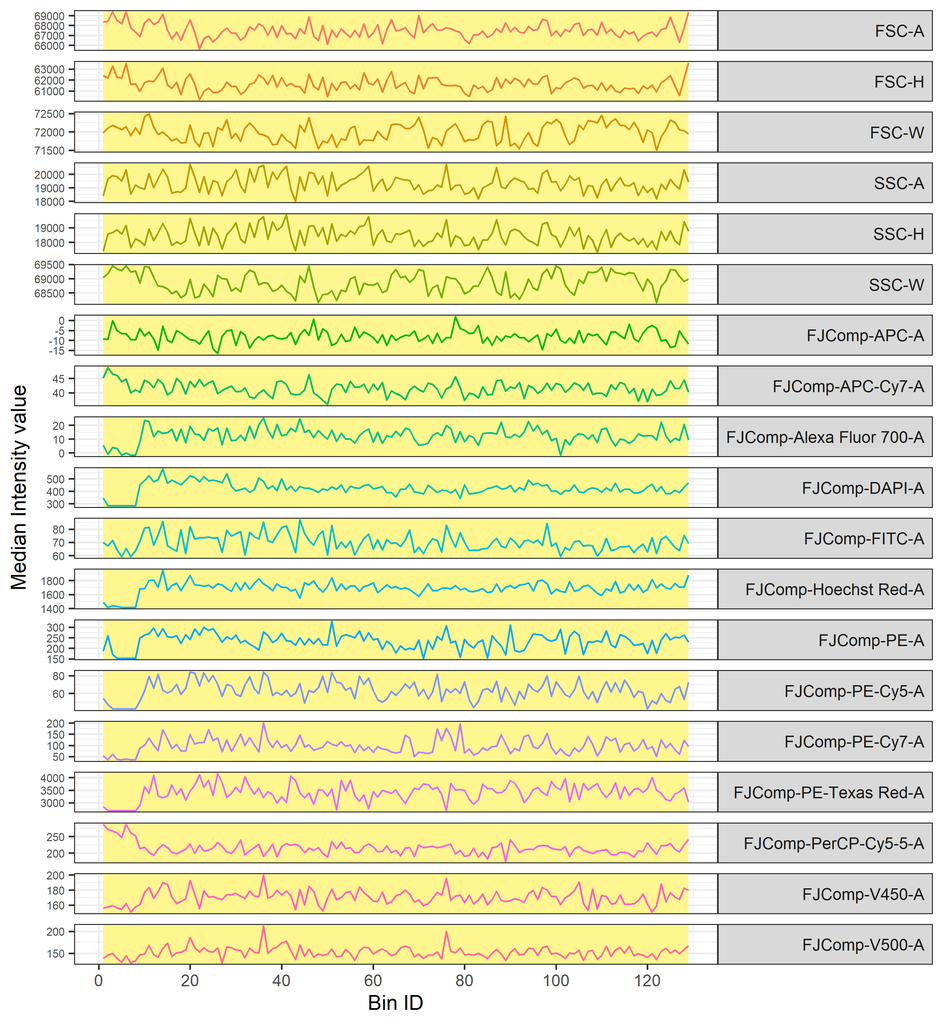

The more stable region selected consistent for all channels is highlighted in yellow. If the removal of outliers has been required before the execution of the changepoint analysis, the detected outliers are cicled in green.

The FCS file was divided in 129 bins, hence each bin contains 498 event(s). The stable region is located between the bins 1 and 129.

##### More info on the changepoints detected

No changepoints were detected.

Channels excluded from the analysis: FSC-A, FSC-H, FSC-W, SSC-A, SSC-H, SSC-W.

No changepoints were detected in the channels: FJComp-APC-A, FJComp-APC-Cy7-A, FJComp-Alexa Fluor 700-A, FJComp-DAPI-A, FJComp-FITC-A, FJComp-Hoechst Red-A, FJComp-PE-A, FJComp-PE-Cy5-A, FJComp-PE-Cy7-A, FJComp-PE-Texas Red-A, FJComp-PerCP-Cy5-5-A, FJComp-V450-A, FJComp-V500-A.

### Dynamic range check

> **4.44** % anomalies detected in dynamic range check.

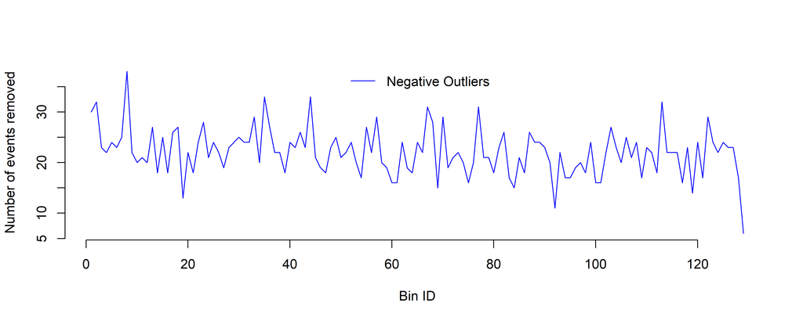

The plot shows where the anomalies occured the most. The x-axis scale is complementary to the one of the signal acquisition plot.

##### More info on the anomalies detected in the dynamic range check

Channels excluded from the analysis: FSC-A, FSC-H, FSC-W, SSC-A, SSC-H, SSC-W.